# Assignment09

2023-06-20

## Recap 1: Gene Expression

```r
head(survey)
```

```
##    gene_id X25_0_r1 X25_0_r2 X25_0_r3 X42_10_r1 X42_10_r2 X42_10_r3 X42_30_r1
## 1 15S_rRNA        2        0        5         0         2         0         1
## 2 21S_rRNA       79       18       33        50        11        12        27
## 3     HRA1        0        0        1         5         2         4         3
## 4     ICR1      105      154      215       208       159       162       297
## 5     LSR1       51        8        9         8        12        12        39
## 6     NME1       23       10       15       172        43        74       104
##   X42_30_r2 X42_30_r3
## 1         2         1
## 2        67        33
## 3         5         8
## 4       495       418
## 5        43        58
## 6       188       161
```

```r
library(tidyverse)
```

```r
library(ggplot2)
```

```r
yeast_log <- survey %>%
  select(-1) %>%
  mutate_all(~ log2(. + 1))

yeast_summary <- yeast_log %>%
  summarize(mean = rowMeans(.),
            sd = apply(., 1, sd, na.rm = TRUE))
```

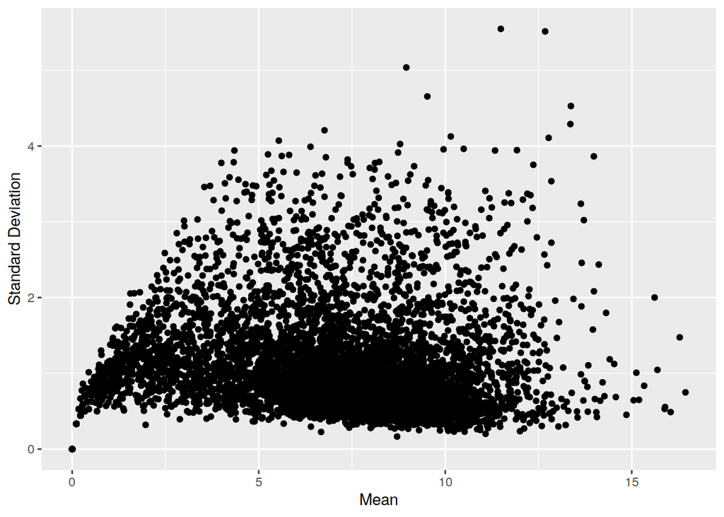

```r
ggplot(yeast_summary, aes(x = mean, y = sd)) +
  geom_point() +
  xlab("Mean") +
  ylab("Standard Deviation")
```

## Plot the expression of ‘YFL014W’ for all replicates, grouping the three replicates of each condition together

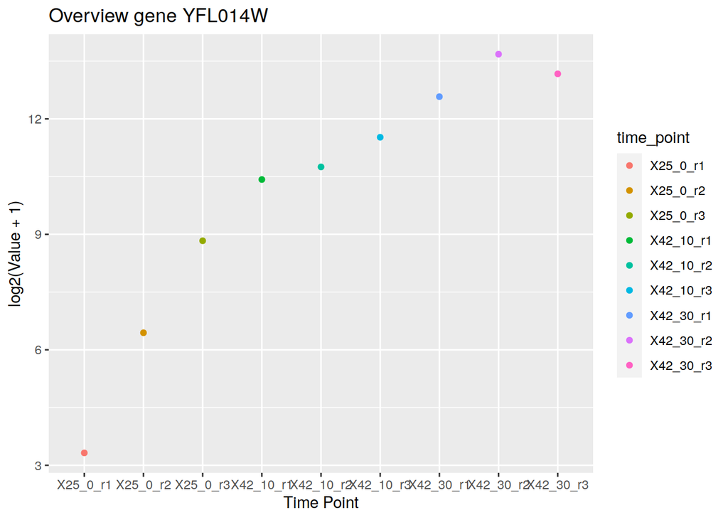

```r
yeast_log <- survey %>%
  select(-1) %>%
  mutate_all(~ log2(. + 1))

gene_yfl014w <- yeast_log %>%
  filter(row_number() %in% grep("YFL014W", survey[, 1])) %>%
  gather(time_point, value)

ggplot(gene_yfl014w, aes(x = time_point, y = value, color= time_point)) +
  geom_point() +
  xlab("Time Point") +
  ylab("log2(Value + 1)") +
  ggtitle("Overview gene YFL014W")
```

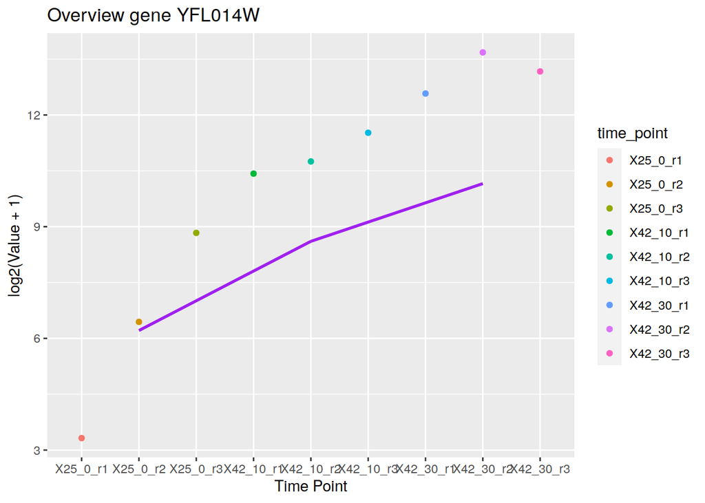

```r
yeast_log <- survey %>%
  select(-1) %>%
  mutate_all(~ log2(. + 1))

gene_yfl014w <- yeast_log %>%
  filter(row_number() %in% grep("YFL014W", survey[, 1])) %>%
  gather(time_point, value)

means <- c(rowMeans(survey[survey$gene_id == "YFL014W", ][2:4]), rowMeans(survey[survey$gene_id == "YFL014W", ][5:7]), rowMeans(survey[survey$gene_id == "YFL014W", ][8:10]))
means <- log(means) + 1


g <- ggplot(gene_yfl014w, aes(x = time_point, y = value, color= time_point)) +
  geom_point() +
  xlab("Time Point") +
  ylab("log2(Value + 1)") +
  ggtitle("Overview gene YFL014W")
g +
  annotate(geom = "segment",
           x = "X25_0_r2", xend = "X42_10_r2",
                   y = means[1], yend = means[2],
               color = "purple", linewidth = 1) +
  annotate(geom = "segment",
           x = "X42_10_r2", xend = "X42_30_r2",
                   y = means[2], yend = means[3],
               color = "purple", linewidth = 1)
```

## Calculate the mean expression per gene per condition. Create two scatter plots: one comparing the means of all genes at 0min and 10min, and the other comparing the means at 10min and 30min.

## Identify genes that consistently exhibit rising or falling expression patterns (e.g.,0min >10min >30min) across the given time steps. Highlight or color these genes in the scatterplot from the previous step.

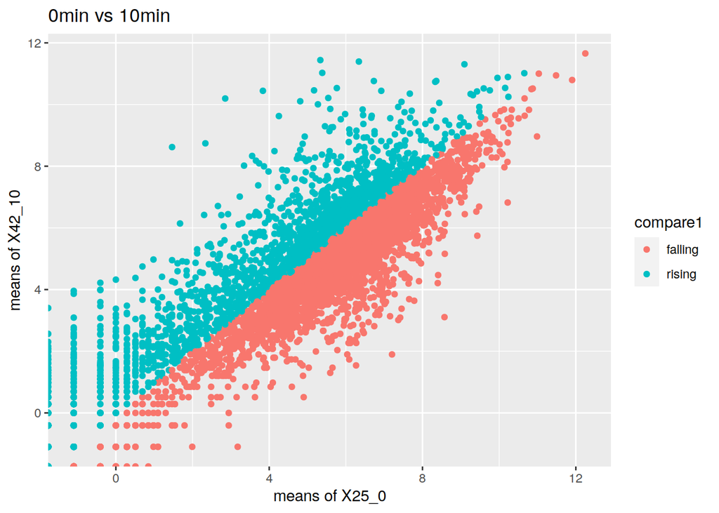

```r
# Create a data frame with means per condition
df <- data.frame(survey$gene_id, rowMeans(survey[2:4]), rowMeans(survey[5:7]), rowMeans(survey[8:10]))
colnames(df)[1] <- "gene_id"
colnames(df)[2] <- "X25_0"
colnames(df)[3] <- "X42_10"
colnames(df)[4] <- "X42_30"
# add new column which shows whether falling or rising
df$compare1 <- "rising"
df$compare1[df$X25_0 > df$X42_10] <- "falling"
df$compare2 <- "rising"
df$compare2[df$X42_10 > df$X42_30] <- "falling"

# Create a scatter plot for the first set of variables
ggplot(df, aes(x = log(df[, 2]), y = log(df[, 3]), color = compare1)) +
  geom_point() +
  labs(title="0min vs 10min",
        x ="means of X25_0", y = "means of X42_10")
```

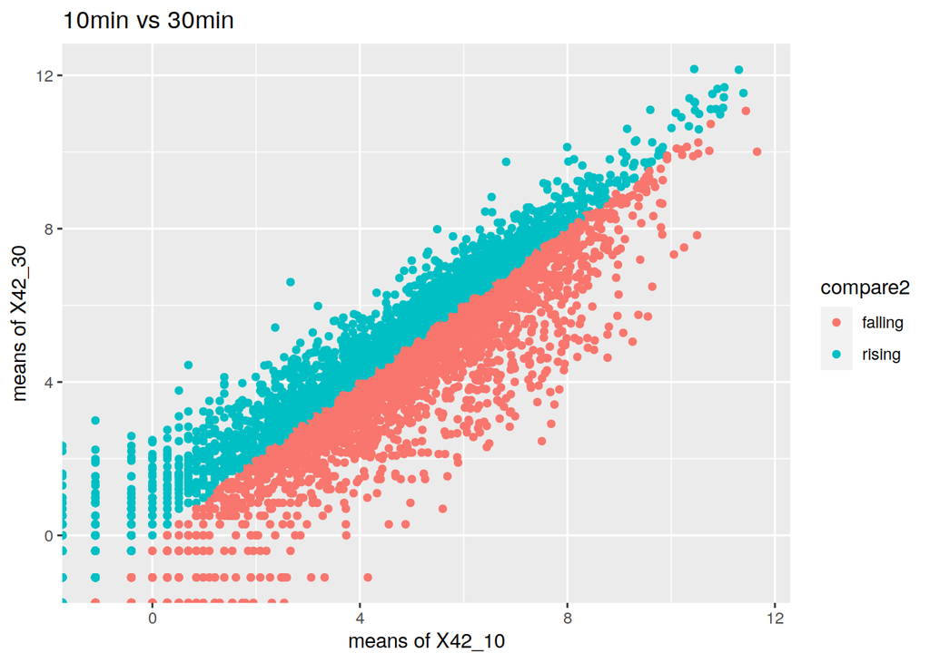

```r
# Create a scatter plot for the second set of variables
ggplot(df, aes(x = log(df[, 3]), y = log(df[, 4]), color = compare2)) +
  geom_point() +
  labs(title="10min vs 30min",
        x ="means of X42_10", y = "means of X42_30")
```

## Task 1: PCA on Gene Expression

```r
library(tidyverse)
#prcomp() function for PCA
#not perfectly sutied for visualization -> use tidy.prcomp()
library(broom)
#install.packages("cowplot")
library(cowplot)
```

In general, when performing PCA, we’ll want to do (at least) three things:

Look at the data in PC coordinates. Look at the rotation matrix. Look at the variance explained by each PC.

```r
#we need numeric columns and we want unit variance:
pca_fit <- survey %>%
  select(where(is.numeric)) %>% # retain only numeric columns
  prcomp(scale = TRUE) # do PCA on scaled data
```

```r
pca_scores <- pca_fit$x
pca_loadings <- pca_fit$rotation

pca_scores <- cbind(pca_scores, survey$gene_id)
colnames(pca_scores)[10] <- "gene_id"

augmented_data <- augment(pca_fit, data=survey)
```

## Plot the PCA for the different samples, using colors to differentiate between conditions:

-> combining the PC coordinates with the original dataset, so we can color points by categorical variables present in the original data but removed for the PCA

Question: why we can’t see different colors here??

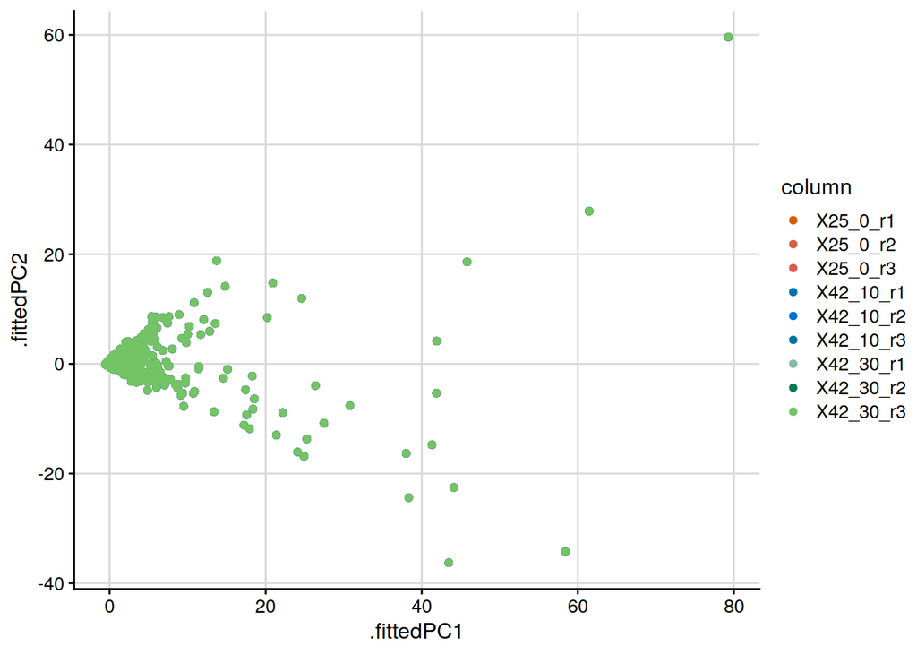

```r
gathered_data <- survey %>%
  select(-1) %>%
  gather(column, value)

pca_fit %>%
  augment(gathered_data) %>% # add original dataset back in
  ggplot(aes(.fittedPC1, .fittedPC2, color=column)) +
  geom_point(size = 1.5) +
  scale_color_manual(
    values = c(X25_0_r1 = "#D55E00", X25_0_r2 = "#D55E40", X25_0_r3 = "#D55E50", X42_10_r1 = "#0072B2", X42_10_r2 = "#0072D3", X42_10_r3 = "#0072A1", X42_30_r1 = "#82BBAB", X42_30_r2 = "#067857", X42_30_r3 = "#74C365")
  ) +
  theme_half_open(12) + background_grid()
```

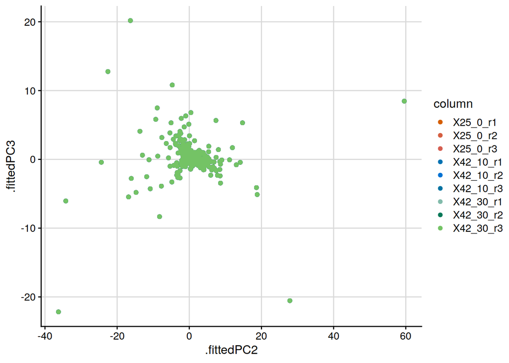

```r
gathered_data <- survey %>%
  select(-1) %>%
  gather(column, value)

pca_fit %>%
  augment(gathered_data) %>% # add original dataset back in
  ggplot(aes(.fittedPC2, .fittedPC3, color=column)) +
  geom_point(size = 1.5) +
  scale_color_manual(
    values = c(X25_0_r1 = "#D55E00", X25_0_r2 = "#D55E40", X25_0_r3 = "#D55E50", X42_10_r1 = "#0072B2", X42_10_r2 = "#0072D3", X42_10_r3 = "#0072A1", X42_30_r1 = "#82BBAB", X42_30_r2 = "#067857", X42_30_r3 = "#74C365")
  ) +
  theme_half_open(12) + background_grid()
```

Looking at data in PC coordinates

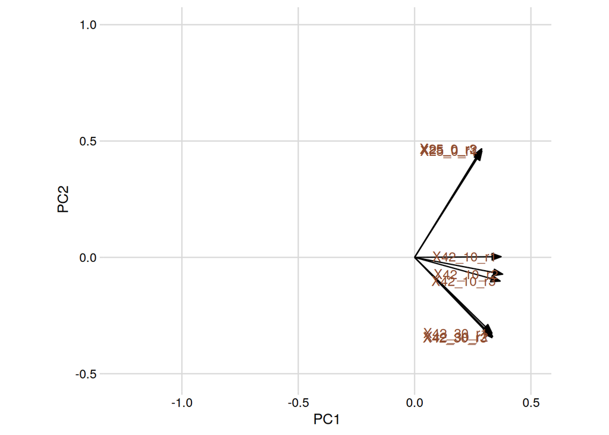

```r
arrow_style <- arrow(
  angle = 20, ends = "first", type = "closed", length = grid::unit(8, "pt")
)

# plot rotation matrix
pca_fit %>%
  tidy(matrix = "rotation") %>%
  pivot_wider(names_from = "PC", names_prefix = "PC", values_from = "value") %>%
  ggplot(aes(PC1, PC2)) +
  geom_segment(xend = 0, yend = 0, arrow = arrow_style) +
  geom_text(
    aes(label = column),
    hjust = 1, nudge_x = -0.02,
    color = "#904C2F"
  ) +
  xlim(-1.25, .5) + ylim(-.5, 1) +
  coord_fixed() + # fix aspect ratio to 1:1
  theme_minimal_grid(12)
```

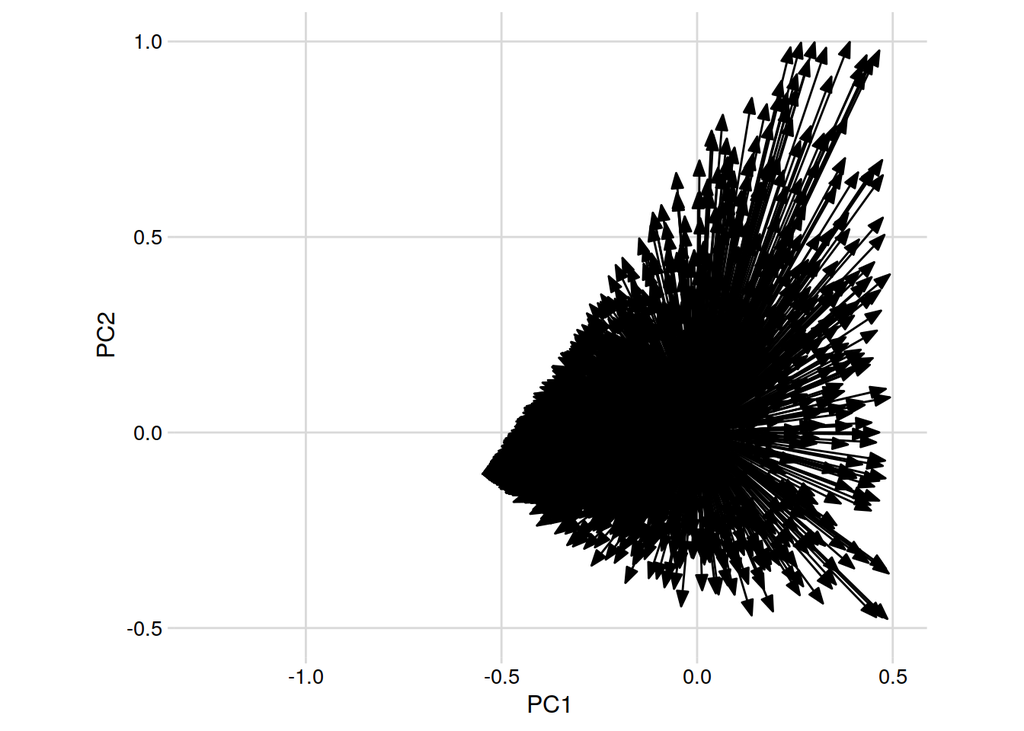

```r
pca_fit %>%
  tidy(matrix = "x") %>%
  pivot_wider(names_from = "PC", names_prefix = "PC", values_from = "value") %>%
  ggplot(aes(PC1, PC2)) +
  geom_segment(xend = 0, yend = 0, arrow = arrow_style) +
  #geom_text(
  # aes(label = row),
  #  hjust = 1, nudge_x = -0.02,
  #  color = "#904C2F"
  #) +
  xlim(-1.25, .5) + ylim(-.5, 1) +
  coord_fixed() + # fix aspect ratio to 1:1
  theme_minimal_grid(12)
```

## Plot the loadings of the PCA:

beide plots

```r
pca_loadings
```

```
##                 PC1          PC2        PC3          PC4         PC5
## X25_0_r1  0.2891386  0.456782715 -0.2350887  0.005432994 -0.04823389
## X25_0_r2  0.2886316  0.466104641 -0.1537197 -0.095096853  0.08818371
## X25_0_r3  0.2874723  0.466558045 -0.1664266  0.008927472  0.03579706
## X42_10_r1 0.3720154  0.002964635  0.4351726  0.599060948 -0.45438004
## X42_10_r2 0.3785557 -0.072186499  0.4461003  0.062788777  0.28963342
## X42_10_r3 0.3677230 -0.101823421  0.4274611 -0.665722446  0.13247400
## X42_30_r1 0.3328304 -0.325745987 -0.3370558 -0.328393049 -0.67837758
## X42_30_r2 0.3352945 -0.340164793 -0.3195784  0.186459980  0.24090970
## X42_30_r3 0.3321622 -0.344977366 -0.3264431  0.205512110  0.40309300
##                   PC6          PC7         PC8         PC9
## X25_0_r1  -0.77210437 -0.230788586  0.01673254 -0.02090948
## X25_0_r2   0.18812898  0.771523585 -0.12950101  0.10759693
## X25_0_r3   0.59840992 -0.539503151  0.11287242 -0.09341334
## X42_10_r1  0.02996921  0.001101742 -0.12684440  0.29982735
## X42_10_r2 -0.06849978  0.131144655  0.34761446 -0.64955547
## X42_10_r3 -0.02997105 -0.168318211 -0.21640816  0.36727549
## X42_30_r1  0.05698697  0.093405629  0.21576916 -0.20722031
## X42_30_r2  0.02243173 -0.076705570 -0.70973430 -0.25849679
## X42_30_r3 -0.01133867  0.016876774  0.48597574  0.47200504
```

```r
head(pca_scores)
```

```
##      PC1                  PC2                   PC3
## [1,] "-0.546169345293252" "-0.105085541482897"  "0.00163137702688201"
## [2,] "-0.52419245693863"  "-0.0995641630607568" "-0.00384627350637999"
## [3,] "-0.545077581200692" "-0.106534282892313"  "0.00206127592950847"
## [4,] "-0.390961867644108" "-0.13471932554179"   "-0.0259133983386501"
## [5,] "-0.530803875001508" "-0.107203422409443"  "-0.00597439963263681"
## [6,] "-0.49054504459641"  "-0.130251212829783"  "0.00448114444721249"
##      PC4                    PC5                    PC6
## [1,] "-0.00688787812251177" "-0.00435148890436744" "-0.0300117636658207"
## [2,] "-0.00032010929545986" "-0.00664793089271643" "-0.0391785175629138"
## [3,] "-0.0065875212508559"  "-0.00435404308584339" "-0.0301390322558397"
## [4,] "0.0106665150829841"   "0.0139746862839455"   "-0.0139642845776145"
## [5,] "-0.00633965980020086" "-0.00289255830631456" "-0.0379505001043614"
## [6,] "0.0116459193616191"   "-0.00868736455776285" "-0.0310208271132672"
##      PC7                  PC8                    PC9
## [1,] "0.0314579924180705" "-0.00487734864002802" "0.00350824799230091"
## [2,] "0.0271484833465348" "-0.00916935434654792" "0.00434859321020551"
## [3,] "0.0318997089854677" "-0.00496876991022694" "0.00468233961890106"
## [4,] "0.0324760927524055" "-0.007795855859442"   "-0.00211112802364235"
## [5,] "0.0301716534489615" "-0.00263287991250791" "0.00439861850878821"
## [6,] "0.0300919298687629" "-0.0118790592341081"  "0.0138313243783358"
##      gene_id
## [1,] "15S_rRNA"
## [2,] "21S_rRNA"
## [3,] "HRA1"
## [4,] "ICR1"
## [5,] "LSR1"
## [6,] "NME1"
```

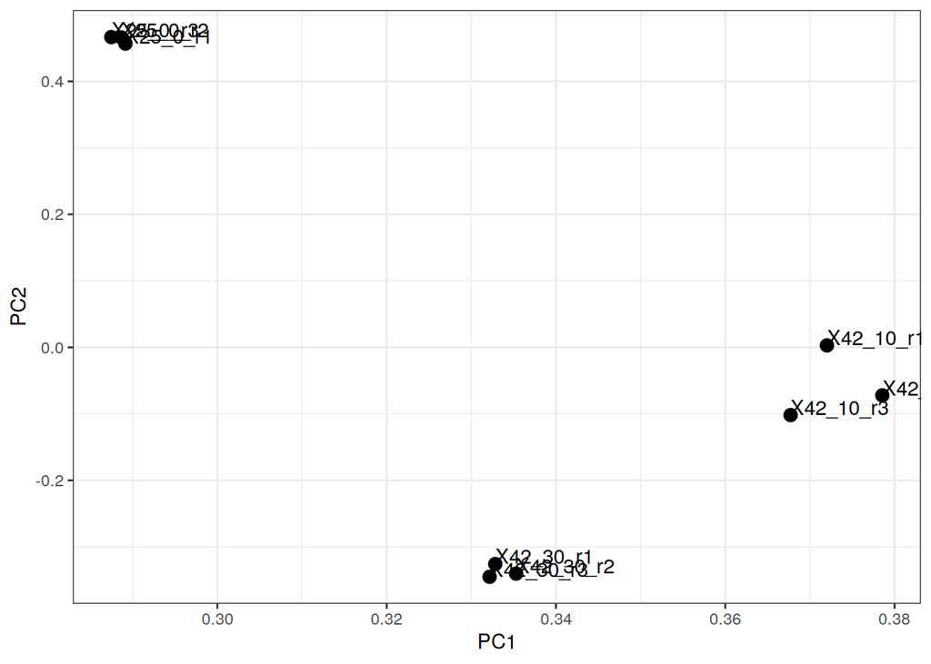

```r
# Extract the loadings from the PCA
loadings <- pca_fit$rotation

# Create a data frame for the loadings
loadings_df <- data.frame(Gene = rownames(loadings),
                          PC1 = loadings[, 1],
                          PC2 = loadings[, 2],
                          PC3 = loadings[, 3],
                          PC4 = loadings[, 4],
                          PC5 = loadings[, 5],
                          PC6 = loadings[, 6],
                          PC7 = loadings[, 7],
                          PC8 = loadings[, 8],
                          PC9 = loadings[, 9])

# Plot the loadings
ggplot(loadings_df, aes(PC1, PC2)) +
  geom_point(size = 3) +
  geom_text(aes(label = Gene), hjust = 0, vjust = 0) +
  labs(x = "PC1", y = "PC2") +
  theme_bw()
```

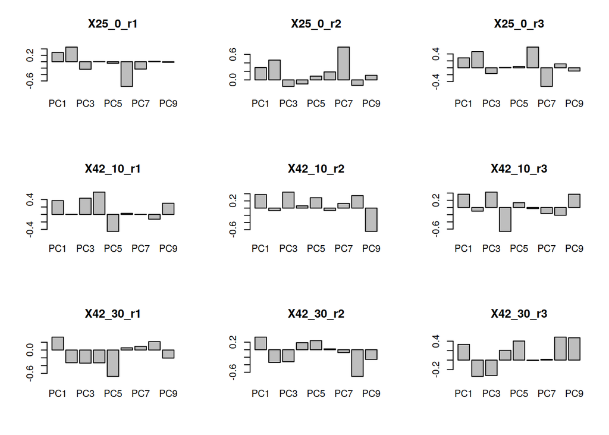

```r
# A different way to plot the loadings
make_plot = function(i) {
  temp_df <- data.frame(  PCs = colnames(pca_loadings),
                          values = pca_loadings[i,])
  barplot(temp_df$values, names.arg = temp_df$PCs, main = rownames(loadings)[i])
}
par(mfrow = c(3, 3))
#somehow it doesn't work with for loop
make_plot(1)
make_plot(2)
make_plot(3)
make_plot(4)
make_plot(5)
make_plot(6)
make_plot(7)
make_plot(8)
make_plot(9)
```

```r
#the variance explained by each PC
pca_fit %>%
  tidy(matrix = "eigenvalues")
```

```
## # A tibble: 9 × 4
##      PC std.dev percent cumulative
##   <dbl>   <dbl>   <dbl>      <dbl>
## 1     1  2.51   0.700        0.700
## 2     2  1.44   0.230        0.930
## 3     3  0.622  0.0429       0.973
## 4     4  0.345  0.0133       0.986
## 5     5  0.231  0.00595      0.992
## 6     6  0.178  0.00353      0.996
## 7     7  0.152  0.00256      0.998
## 8     8  0.0989 0.00109      0.999
## 9     9  0.0767 0.00065      1
```

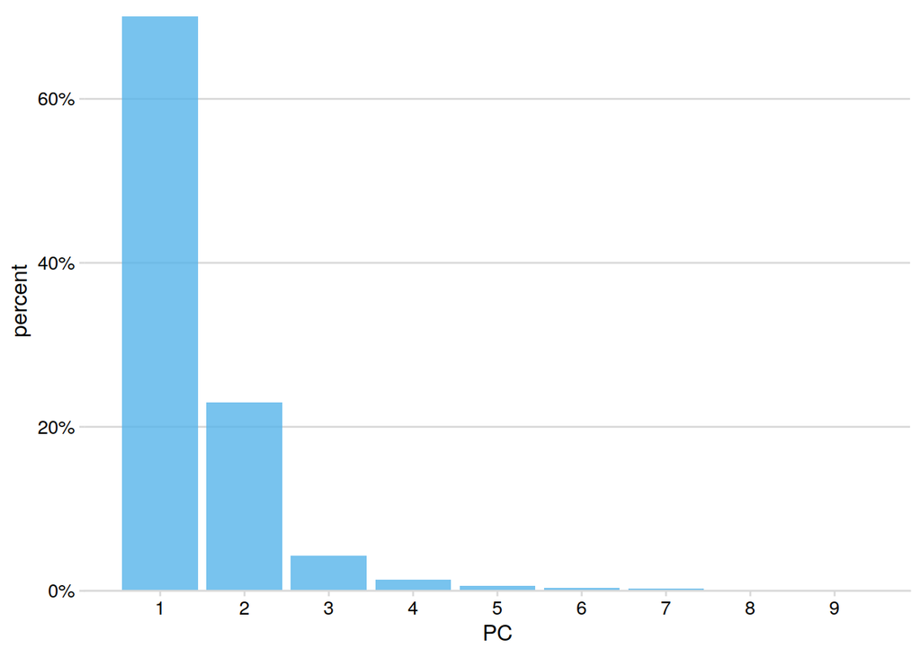

```r
pca_fit %>%
  tidy(matrix = "eigenvalues") %>%
  ggplot(aes(PC, percent)) +
  geom_col(fill = "#56B4E9", alpha = 0.8) +
  scale_x_continuous(breaks = 1:9) +
  scale_y_continuous(
    labels = scales::percent_format(),
    expand = expansion(mult = c(0, 0.01))
  ) +
  theme_minimal_hgrid(12)
```

##Identify most influential genes along with their loadings per PC and create plot Determine the genes with the highest absolute loading values in the principal component. These genes are considered the most influential for that principal component.

```r
cbind(pca_loadings, total = rowSums(pca_loadings))
```

```
##                 PC1          PC2        PC3          PC4         PC5
## X25_0_r1  0.2891386  0.456782715 -0.2350887  0.005432994 -0.04823389
## X25_0_r2  0.2886316  0.466104641 -0.1537197 -0.095096853  0.08818371
## X25_0_r3  0.2874723  0.466558045 -0.1664266  0.008927472  0.03579706
## X42_10_r1 0.3720154  0.002964635  0.4351726  0.599060948 -0.45438004
## X42_10_r2 0.3785557 -0.072186499  0.4461003  0.062788777  0.28963342
## X42_10_r3 0.3677230 -0.101823421  0.4274611 -0.665722446  0.13247400
## X42_30_r1 0.3328304 -0.325745987 -0.3370558 -0.328393049 -0.67837758
## X42_30_r2 0.3352945 -0.340164793 -0.3195784  0.186459980  0.24090970
## X42_30_r3 0.3321622 -0.344977366 -0.3264431  0.205512110  0.40309300
##                   PC6          PC7         PC8         PC9      total
## X25_0_r1  -0.77210437 -0.230788586  0.01673254 -0.02090948 -0.5390381
## X25_0_r2   0.18812898  0.771523585 -0.12950101  0.10759693  1.5318519
## X25_0_r3   0.59840992 -0.539503151  0.11287242 -0.09341334  0.7106941
## X42_10_r1  0.02996921  0.001101742 -0.12684440  0.29982735  1.1588875
## X42_10_r2 -0.06849978  0.131144655  0.34761446 -0.64955547  0.8655956
## X42_10_r3 -0.02997105 -0.168318211 -0.21640816  0.36727549  0.1126903
## X42_30_r1  0.05698697  0.093405629  0.21576916 -0.20722031 -1.1778006
## X42_30_r2  0.02243173 -0.076705570 -0.70973430 -0.25849679 -0.9195839
## X42_30_r3 -0.01133867  0.016876774  0.48597574  0.47200504  1.2328657
```

```r
max(rowSums(pca_loadings))
```

```
## [1] 1.531852
```

So X25_0_r2 is the most influential gene. And we will make plots of the loadings per PC

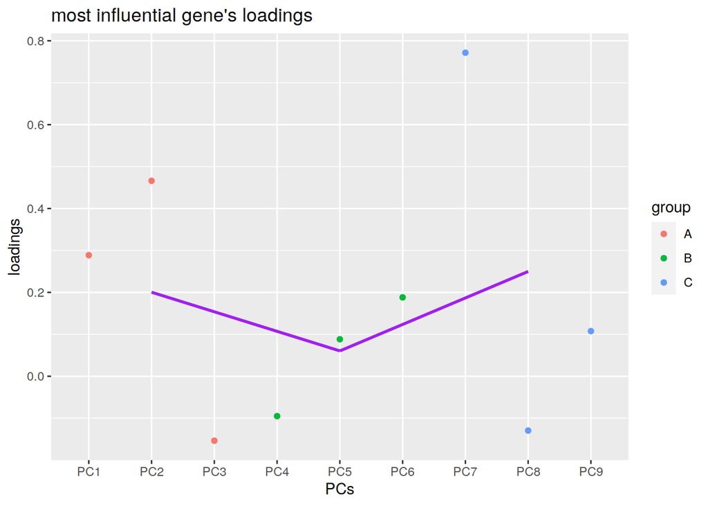

```r
X25_0_r2_df <- data.frame(  PCs = colnames(pca_loadings),
                          values = pca_loadings[2,],
                          group = c("A", "A", "A", "B", "B", "B", "C", "C", "C"))

means <- c(mean(X25_0_r2_df$values[1:3]), mean(X25_0_r2_df$values[4:6]), mean(X25_0_r2_df$values[7:9]))

g <- ggplot(X25_0_r2_df, aes(x = PCs, y = values, color= group)) +
  geom_point() +
  xlab("PCs") +
  ylab("loadings") +
  ggtitle("most influential gene's loadings")

g +
  annotate(geom = "segment",
           x = "PC2", xend = "PC5",
                   y = means[1], yend = means[2],
               color = "purple", linewidth = 1) +
  annotate(geom = "segment",
           x = "PC5", xend = "PC8",
                   y = means[2], yend = means[3],
               color = "purple", linewidth = 1)
```

## Color the loadings of the genes in the mean expression scatterplot between two conditions, following the style of ‘Recap 1 plot 4+5’. Perform this task for PC1 and PC2.

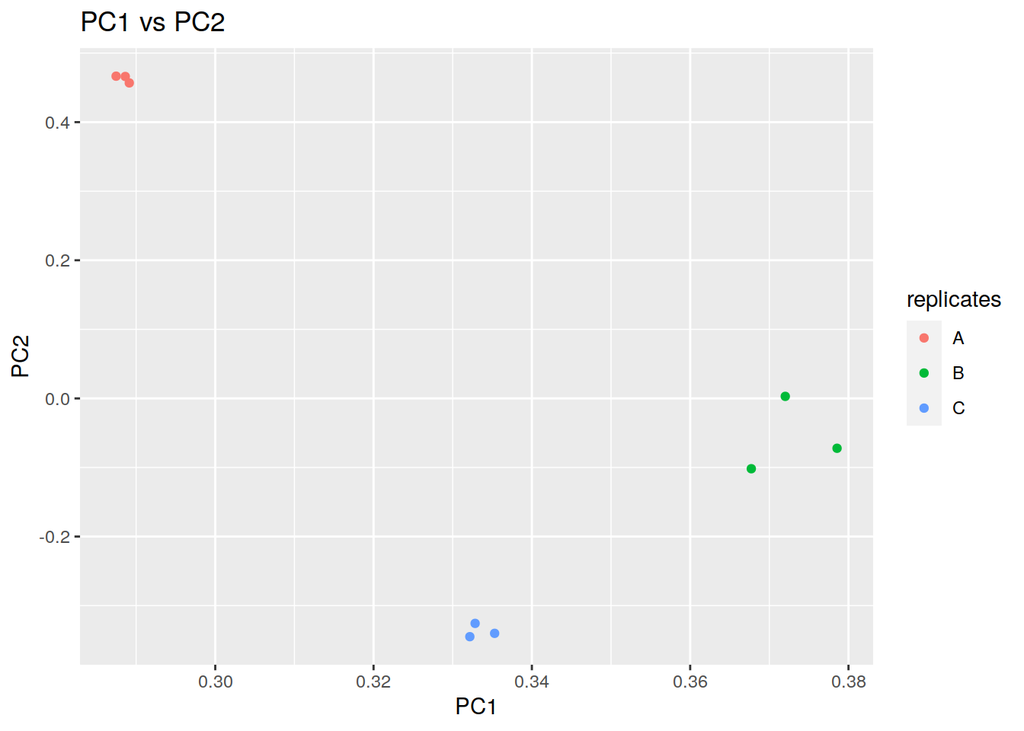

```r
pca_loadings <- data.frame(pca_loadings)
replicates <- c("A", "A", "A", "B", "B", "B", "C", "C", "C")
ggplot(pca_loadings, aes(x = pca_loadings[, 1], y = pca_loadings[, 2], color = replicates)) +
  geom_point() +
  labs(title="PC1 vs PC2", x ="PC1", y = "PC2")
```